# Lição n° 5 GitHub

Construindo gráficos com ggplot2

Naiara Ferreira de Jesus

06/09/2021

## Introdução

Irei analisar alguns conjutos de dados para a contrução de gráficos. Os *datasets* utilizados são :`dados_mpg` ,`co2_tidy` e `titanic`.

carregando os pacotes

```r
library(tidyverse)
library(scales)
```

## 1. Gráfico de Pontos

O *dataset* usado, é o `dados_mpg`, para observarmos as cilindradas e tração por de milhas por galão nas cidades.

```r
# Lendo conjunto de dados " milhas_por_galão.csv"
dados_mpg <-read.csv("dados/milhas_por_galao.csv")
```

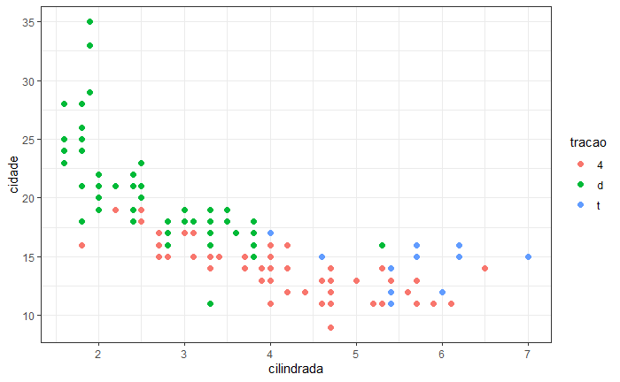

```r
ggplot(data = dados_mpg) +
  aes(x = cilindrada, y = cidade) +
  geom_point(size = 2, aes(color = tracao))+
  theme_bw()
```

## 2. Gráfico de linhas

O *dataset* usado é o `co2_tidy`, onde iremos observar a média de CO2 dentre desse período de 1959 até 1997.

```r
# Lendo conjunto de dados "co2_tidy.csv"
co2_tidy <- read.csv("dados/co2_tidy.csv")
```

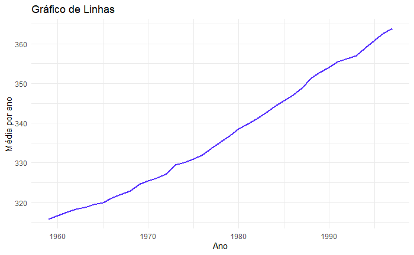

```r
mpa <-co2_tidy %>%
  group_by(ano) %>%
  summarise(
    media_ppm = round(mean(ppm),1)
  )
mpa %>%
  ggplot(aes(x = ano, y = media_ppm, group = 1)) +
  geom_line(color = "#5833FF", size = 1) +
  labs(
    title = "Gráfico de Linhas ",
    x = "Ano",
    y = "Média por ano"
  ) +
  theme_minimal()
```

Com o passar dos anos dentro desse príodo,a média ppm não teve diminuição significativa,mantendo-se de forma crescente.

## 3. Gráfico de Barras

O *dataset* usado é o `dados_mpg`: Vamos observar as porcentagens de trasmissões dos carros

[figure not shown]

```r
dados_mpg %>%
  count(transmissao) %>%
  mutate(prop = n / sum(n)) %>%
  ggplot() +
  aes(x = prop, y = fct_reorder(transmissao, prop),fill = transmissao) +
  geom_col() +
  scale_fill_viridis_d() +
  scale_x_continuous(
    labels = label_percent(accuracy = 1),
    limits = c(0, .3)
  ) +
  labs(
    title = "Porcentagem de transmissões dos Carros",
    x = "",
    y = ""
  ) +
  theme_minimal()
```

## 4. Gráfico Histograma

O *dataset* usado é o `dados_mpg`:

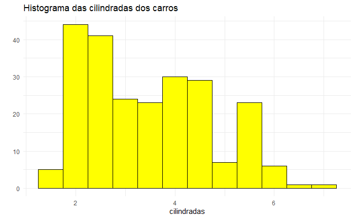

```r
dados_mpg %>%
  ggplot() +
  aes(x = cilindrada) +
  geom_histogram(fill = "yellow", color = "black", binwidth = 0.5) +
  labs(
    title = "Histograma das cilindradas dos carros",
    x = "cilindradas",
    y = ""
  ) +
  theme_minimal()
```

A quantidade de carros com cilindradas de 1 até seis é bem superior dos que possuem cilindradas maiores que seis.

## 5. Gráfico de Densidade

O *dataset* usado é o`titanic` : Vamos observar a concentração de idades que os passageiros possuiam

```r
# Lendo conjunto de dados "titanic.csv"
titanic <-read.csv("dados/titanic.csv")
```

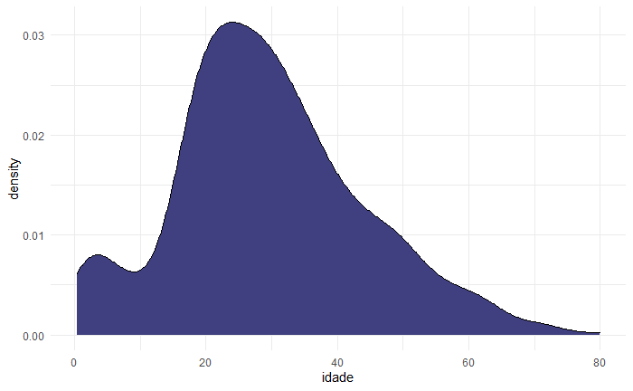

```r
titanic%>%
  ggplot() +
  aes(x = idade) +
  geom_density(fill = "#404080") +

  theme_minimal()
```

```r
NA
```

A maior concentração de idade está entre de 20 a 30 anos, sendo assim as idades de grande parte dos passageiros.

## 6. Boxplot

O *dataset* usado é o`titanic` : Onde iremos observar o sexo e a idades dos sobrevinetes e não sobreviventes

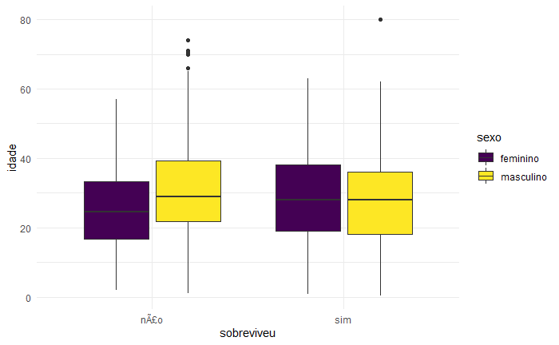

```r
titanic %>%
  ggplot() +
  aes(x= sobreviveu, y = idade, fill= sexo) +
  geom_boxplot() +
  scale_fill_viridis_d()+

  theme_minimal()
```

Podemos observar que os as pessoas com 60 anos ou mais que não sobreviveram foram do sexo masculino, onde está constando idades muito distantes das outras observadas.